# Flow Control and Function

2022-11-15

```r
library(tidyverse)
```

# Flow Control

Some sontrol statements affect or control the execution of other statements in some way.

## `ifelse()` Function’

Syntax:

```
ifelse(testexpression, yes, no)
```

*Example 1*: Convert a character vector to a numeric vector

```r
x <- c("female", "male", "male", "female", "female", "male", "female")

ifelse(x == "female", 0, 1)
```

```
## [1] 0 1 1 0 0 1 0
```

*Example 2*: Convert uniform random numbers to binomial random numbers.

`rXXX(size, parameters of distribution)` create random numbers from some specific probability distribution

```r
set.seed(23)
x <- runif(10,0,6) # Create random numbers from a uniform distribution from (0,6)

ifelse(x > 3, 1, 0)
```

```
##  [1] 1 0 0 1 1 0 1 1 1 1
```

*Example 3*: Import `gss_cat` dataset, create a new variable `racenew` only with values `0` and `1`, where `1` represents white, and `0` represents non-white.

```r
gss_cat %>%
  mutate(racenew = ifelse(race == "White", 1, 0)) %>%
  head(10)
```

```
## # A tibble: 10 × 10
##     year marital         age race  rincome   partyid relig denom tvhours racenew
##    <int> <fct>         <int> <fct> <fct>     <fct>   <fct> <fct>   <int>   <dbl>
##  1  2000 Never married    26 White $8000 to… Ind,ne… Prot… Sout…      12       1
##  2  2000 Divorced         48 White $8000 to… Not st… Prot… Bapt…      NA       1
##  3  2000 Widowed          67 White Not appl… Indepe… Prot… No d…       2       1
##  4  2000 Never married    39 White Not appl… Ind,ne… Orth… Not …       4       1
##  5  2000 Divorced         25 White Not appl… Not st… None  Not …       1       1
##  6  2000 Married          25 White $20000 -… Strong… Prot… Sout…      NA       1
##  7  2000 Never married    36 White $25000 o… Not st… Chri… Not …       3       1
##  8  2000 Divorced         44 White $7000 to… Ind,ne… Prot… Luth…      NA       1
##  9  2000 Married          44 White $25000 o… Not st… Prot… Other       0       1
## 10  2000 Married          47 White $25000 o… Strong… Prot… Sout…       3       1
```

## `if() else` statement

The `if() else` statement allows us to control which statements are executed.

Syntax:

```
if (condition) {commands when condition is TRUE}
else {commands when condition is FALSE}
```

```r
x <- 5

if (x < 0) {
  print("negative")
} else {
  print("non-negative")
}
```

```
## [1] "non-negative"
```

Sometimes, when there is only one command to execute, we can omi `{}`.

We can also omit `print()`.

```r
x <- c("female", "male")

if (is.numeric(x)) "numeric vector" else "non-numeric vector"
```

```
## [1] "non-numeric vector"
```

AND operator

```r
x <- 15

if (x > 0 & x < 10) {
  print("target")
} else {
  print("error")
}
```

```
## [1] "error"
```

OR operator

```r
x <- -5

if (x > 0 | x < 0) {
  print("non-zero number")
} else {
  print("zero")
}
```

```
## [1] "non-zero number"
```

NOT operator

```r
if (!FALSE){
  cat("this statement will show up")
}
```

```
## this statement will show up
```

## Nested `if() else` statement

Syntax:

```
if (test_expression1) {
  statement 1
} else if (test_expression2) {
  statement 2
} else if (test_expression3) {
  statement 3
} else {
  statement 4
}
```

```r
x <- 15

if (x<0) {
  print("negative number")
} else if (x > 0) {
  print("positive number")
} else {
  print("zero")
}
```

```
## [1] "positive number"
```

```r
set.seed(111)
grade <- rnorm(1, 50, 50)

if (grade > 90) {
  print("A")
} else if (grade > 80 & grade <= 90) {
  print("B")
} else if (grade > 70 & grade <= 80) {
  print("C")
} else {
  print("D")
}
```

```
## [1] "D"
```

# The `for` Loop

The `for` loop controls how many times the statement are repeated.

If we want to run the same block of code multiple times, the `for()` loop statement allows one to specify that a certain operation should be repeated a fixed number of times.

## Iteration `n` times over an index

*Example 1*: Calculate the sum from 1 to 100.

```r
n <- 100
x <- 0 # Initial value

for (i in 1:n) {
  x <- x + i
}
x
```

```
## [1] 5050
```

*Example 2*: Adding stuff to a vector

```r
set.seed(1234)
random_numbers <- NULL # Create a vector with no elements

for (i in 1:10) {
  random_numbers <- c(random_numbers, runif(1)) # runif(1) creates random numbers from a uniform distribution in [0,1]
}

cat(random_numbers)
```

```
## 0.1137034 0.6222994 0.6092747 0.6233794 0.8609154 0.6403106 0.009495756 0.2325505 0.6660838 0.5142511
```

## Iterate over all items in a vector

*Example 1*: In R, we have some US state facts and figures. Find all the states starting with the letter `M`.

```r
Mstates <- NULL

for (x in state.name) {
  if (substr(x, 1, 1) == "M") {
    Mstates <- c(Mstates, x)
  }
}
Mstates
```

```
## [1] "Maine"         "Maryland"      "Massachusetts" "Michigan"
## [5] "Minnesota"     "Mississippi"   "Missouri"      "Montana"
```

*Example 2*: Central Limit Theorem **Central Limit Theorem (CLT)**: the distribution of sample means approximates a normal distribution as the sample size gets larger, regardless of the population’s distribution. i.e., The sampling distribution (histogram) of sample means (selection with random sample size) from a (fixed) population is approximately normal.

```r
pop <- 1:100
size <- 10
iteration <- 10000
sample <- NULL
```

$\boxed{\text{Method 1}}$: Use the `for()` Loop

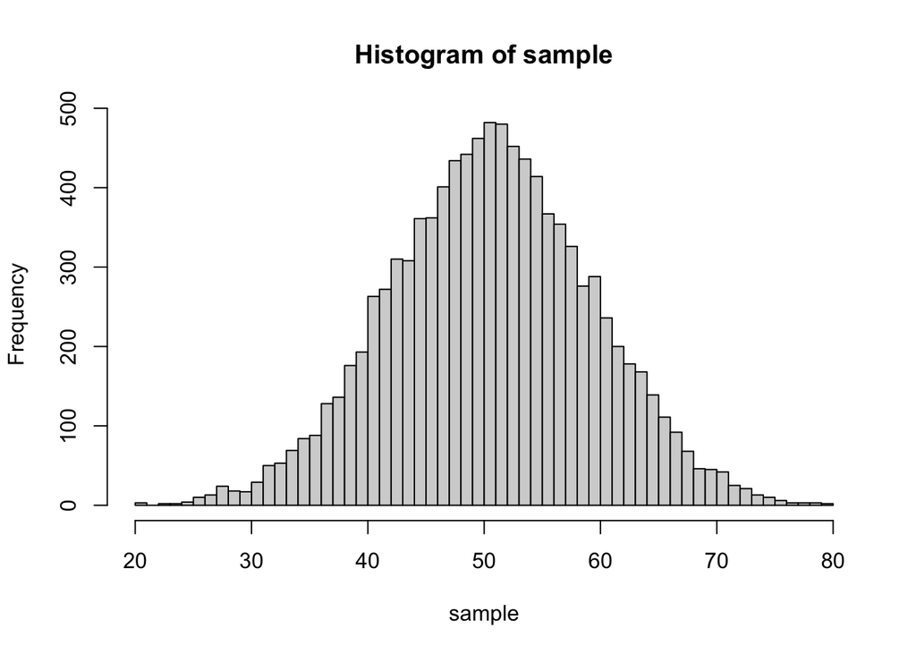

```r
set.seed(1108)

for (i in 1:iteration) {
  x <- mean(sample(pop, size, replace = FALSE))
  sample <- c(sample, x)
}

hist(sample, breaks = 50)
```

$\boxed{\text{Method 2}}$: We can also use `replicate()` function. The syntax goes follows:

```
replicate(#of\repetition, expression)
```

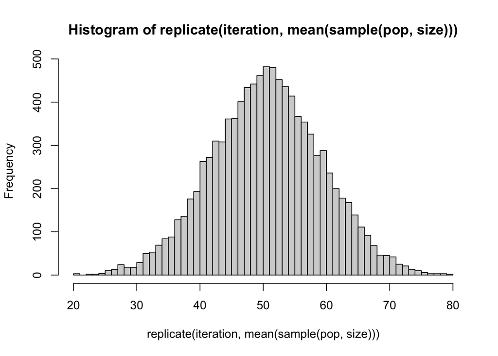

```r
set.seed(1108)

hist(replicate(iteration, mean(sample(pop, size))), breaks = 50)
```

*Example 3*: get the average grades for each student

```r
# Look at the data set
set.seed(1000)

exams <- list(
  student1 = round(runif(10, 50, 100)),
  student2 = round(runif(10, 50, 100)),
  student3 = round(runif(10, 50, 100)),
  student4 = round(runif(10, 50, 100)),
  student5 = round(runif(10, 50, 100))
)

exams
```

```
## $student1
##  [1] 66 88 56 85 76 53 87 79 61 63
##
## $student2
##  [1] 67 88 66 93 88 54 75 82 54 79
##
## $student3
##  [1] 58 90 64 54 77 84 73 91 55 56
##
## $student4
##  [1] 78 52 78 98 75 85 51 89 79 66
##
## $student5
##  [1] 100  77  55  82  90  86  85  78  63  75
```

```r
mean(exams)
```

```
## [1] NA
```

This is because, we need `[[]]` to extract the values in the vector format instead of single bracket:

```r
exams[[1]]
```

```
##  [1] 66 88 56 85 76 53 87 79 61 63
```

If we use single bracket `[]`, we will get the result not in the vector format. The result will be in the list format.

```r
exams[1]
```

```
## $student1
##  [1] 66 88 56 85 76 53 87 79 61 63
```

What we can do:

```r
list(
  student1 = mean(exams$student1),
  student2 = mean(exams$student2),
  student3 = mean(exams$student3),
  student4 = mean(exams$student4),
  student5 = mean(exams$student5)
)
```

```
## $student1
## [1] 71.4
##
## $student2
## [1] 74.6
##
## $student3
## [1] 70.2
##
## $student4
## [1] 75.1
##
## $student5
## [1] 79.1
```

However, when the number of students gets larger, this method is very not efficient.

$\boxed{\text{Method 1}}$: We can use `for()` loop instead.

```r
mean_score = NULL

for (i in seq_along(exams)){
  mean_score = c(mean_score, mean(exams[[i]]))
}

mean_score
```

```
## [1] 71.4 74.6 70.2 75.1 79.1
```

`seq_along()` gives a vector including all the index of the argument.

$\boxed{\text{Method 2}}$: We can also use `Xapply()` function.

```r
lapply(exams, mean) # lapply will return another list
```

```
## $student1
## [1] 71.4
##
## $student2
## [1] 74.6
##
## $student3
## [1] 70.2
##
## $student4
## [1] 75.1
##
## $student5
## [1] 79.1
```

```r
sapply(exams, mean) # sapply will return the result in vecotr format
```

```
## student1 student2 student3 student4 student5
##     71.4     74.6     70.2     75.1     79.1
```

*Extension*: Find the range of grades that each student get from the exams.

```r
range = NULL

for (i in seq_along(exams)) {
  range <- c(range, max(exams[[i]]) - min(exams[[i]]))
}

range
```

```
## [1] 35 39 37 47 45
```

# Function

We have been using many functions in R, now we learn to write them ourselves. We will use the `function()` function to create functions. Syntax:

- Functions that include one input and one output

```
function_name <- function(input) {
  Body of the function
  Output value (return)
}
```

- Functions that include multiple inputs and outputs

```
function_name <- function(input1, input2, input3, ...) {
  Body of the function
  return(list = c(output1, output2, output3, ...))
}
```

- When recalling the function, we simple use

```
function_name(input)
```

*Example 1*: Create a mean function

```r
my_mean <- function(x) {
  m <- sum(x) / length(x)
  return(m)
}

my_mean(c(1:10))
```

```
## [1] 5.5
```

Functions can be declared and used inside a function. Functions in R can also return functions.

*Example 2*: Create a mean function for inputs including `NA` values

```r
my_mean <- function(x) {
  if (sum(is.na(x)) > 0) {
    x <- na.omit(x)
  }
  m <- sum(x) / length(x)
    return(m)
}

my_mean(c(1:5, NA))
```

```
## [1] 3
```

Or, we can let the user to choose if they want the `NA` to be omitted or not.

```r
my_mean <- function(x, na.rm) {
  if (na.rm == TRUE) {
    if (sum(is.na(x)) > 0) {
      x <- na.omit(x)
    }
  }
  m <- sum(x) / length(x)
  return(m)
}

my_mean(c(1:5, NA), na.rm = TRUE)
```

```
## [1] 3
```

```r
my_mean(c(1:5, NA), na.rm = FALSE)
```

```
## [1] NA
```

*Example 3*: Get some summaries of a numeric vector

```r
summaries <- function(x) {
  return(list = c(min(x), max(x), mean(x), median(x), sd(x), length(x)))
}

summaries(c(1:15))
```

```
## [1]  1.000000 15.000000  8.000000  8.000000  4.472136 15.000000
```

*Example 4*: Make a function to calculate the range

```r
my_range <- function(x) {
  r <- max(x) - min(x)
  return(r)
}

my_range(1:100)
```

```
## [1] 99
```

Or we can combine the `range()` function in R to write `my_range()` function

```r
my_range <- function(x) {
  r <- range(x)[2] - range(x)[1]
  return(r)
}

my_range(1:100)
```

```
## [1] 99
```

*Example 5*: Make a re-scale function that re-scale all the numbers in a vector to [0,1] We can use the following function to re-scale:
$$x_r=\frac{x-\min{x}}{\max{x}-\min{x}},$$
where $x_r$ is the re-scaled $x$ value.

```r
rescale <- function(x) {
  (x-min(x)) / my_range(x)
}

rescale(1:10)
```

```
##  [1] 0.0000000 0.1111111 0.2222222 0.3333333 0.4444444 0.5555556 0.6666667
##  [8] 0.7777778 0.8888889 1.0000000
```

*Example 6*: Plot a function $\boxed{\text{Method 1}}$

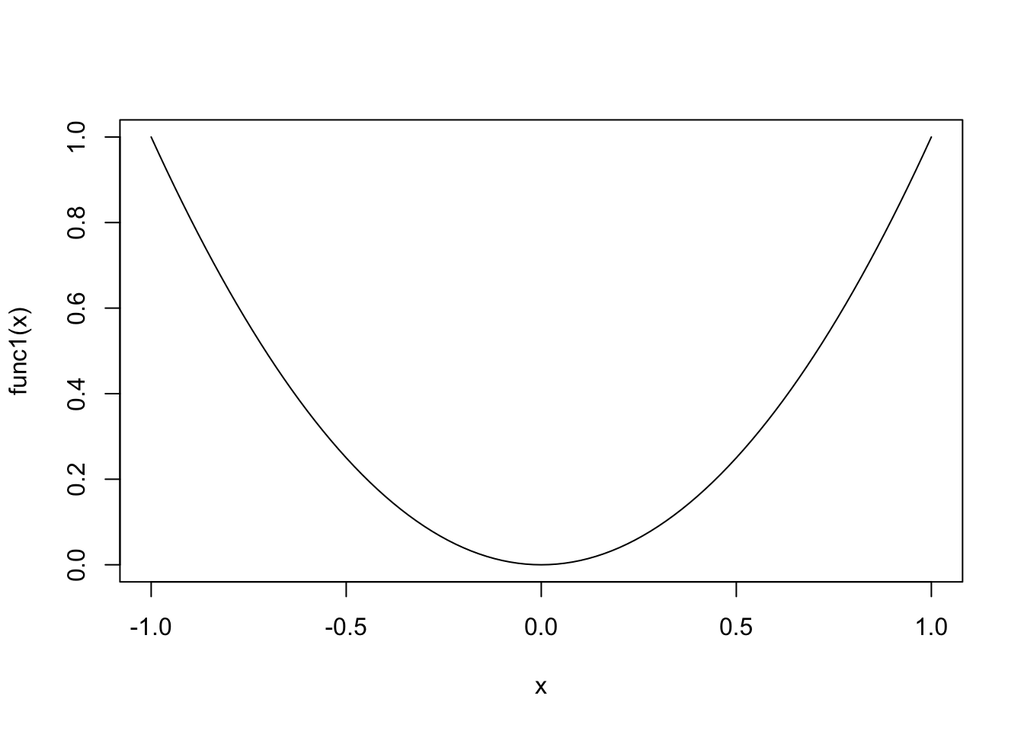

```r
func1 <- function(x) {
  x^2
}

curve(func1,-1,1)
```

$\boxed{\text{Method 2}}$

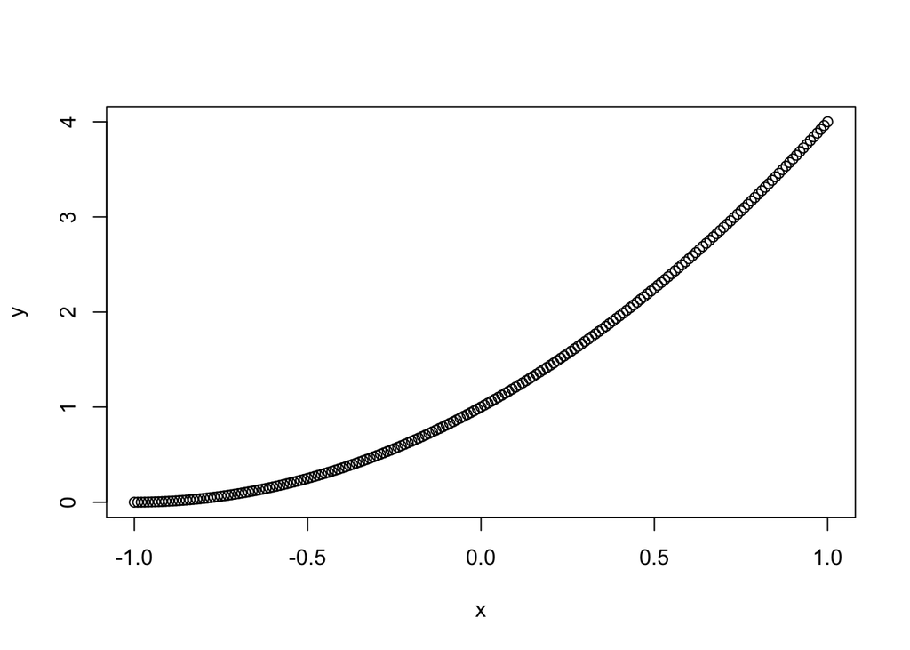

```r
fun2<-function (x) {
  y<-x^2+2*x+1
  plot(x,y)
}

fun2(seq(-1,1,0.01))
```

$\boxed{\text{Method 3}}$

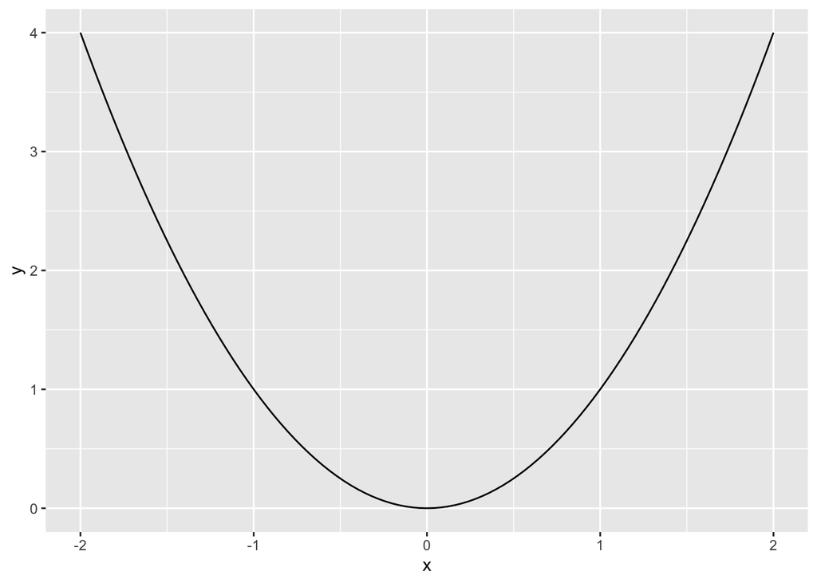

```r
ggplot(data=data.frame(x=c(-2,2)), aes(x=x))+
  stat_function(fun=func1)+
  xlim(c(-2,2))
```

We can also use `optimize()` to find the minimum for the function at (0,0)

```r
optimize(func1, interval=c(-2,2))
```

```
## $minimum
## [1] -5.551115e-17
##
## $objective
## [1] 3.081488e-33
```

*Example 7*

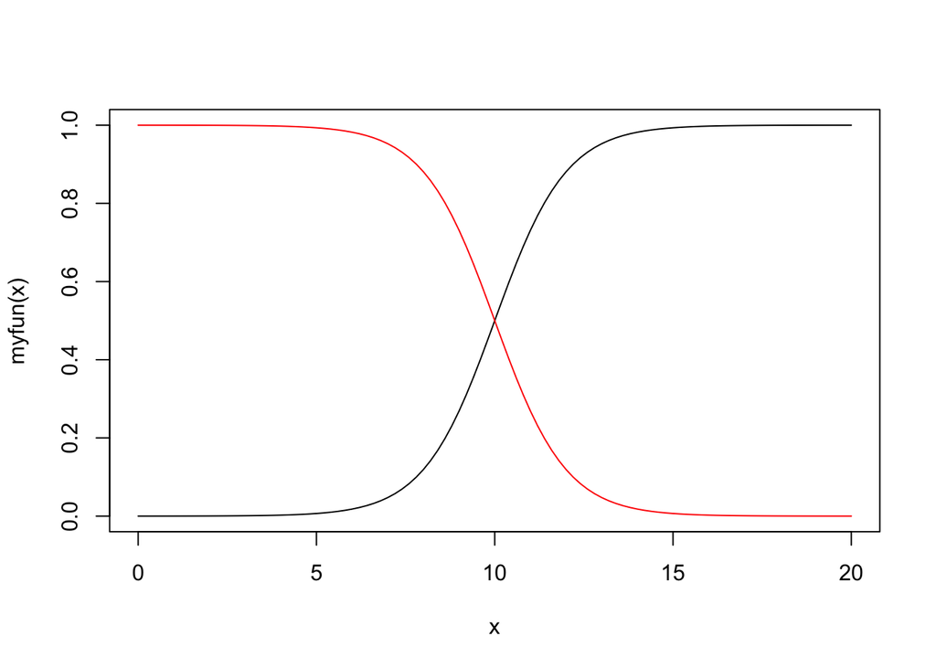

```r
myfun <- function(x) {
  1 / (1 + exp(-x + 10))
}
curve(myfun(x), from = 0, to = 20)
curve(1 - myfun(x), add = TRUE, col = "red") # Add a line
```

*Example 8*: Create a function to print all the summaries Note: If we do not want to use `return(list = c(output1, output2, output3,...)`, we can also use `print()` to print each output.

```
## [1] 100
##    Min. 1st Qu.  Median    Mean 3rd Qu.    Max.
## -2.3225 -0.4095  0.1874  0.1155  0.7067  2.5540
## [1] 0.1154781
## [1] 0.992918
##         0%        25%        50%        75%       100%
## -2.3224909 -0.4094833  0.1873768  0.7066787  2.5539880
```

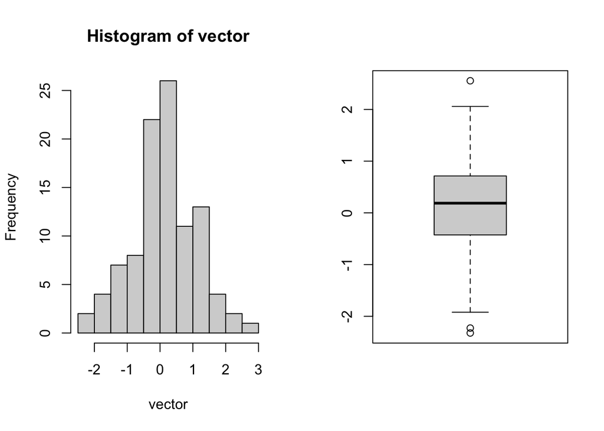

```r
summaries <- function (vector) {
  print(length(vector))
  print(summary(vector))
  print(mean(vector,na.rm = T))
  print(sd(vector,na.rm=T))
  print(quantile(vector))
  par(mfrow=c(1,2))
  hist(vector)
  boxplot(vector)
}

x <- rnorm(100)
summaries(x)
```

# The `purrr` Package

The function in `purrr` makes iteration easier.

Recall the data set including students exam results over the semester.

```r
# rXXX(size, parameters of this distribution) to create random numbers from a specific probability distribution
set.seed(1000)
exams <- list(
  student1 = round(runif(10, 50, 100)),
  student2 = round(runif(10, 50, 100)),
  student3 = round(runif(10, 50, 100)),
  student4 = round(runif(10, 50, 100)),
  student5 = round(runif(10, 50, 100))
)
exams
```

```
## $student1
##  [1] 66 88 56 85 76 53 87 79 61 63
##
## $student2
##  [1] 67 88 66 93 88 54 75 82 54 79
##
## $student3
##  [1] 58 90 64 54 77 84 73 91 55 56
##
## $student4
##  [1] 78 52 78 98 75 85 51 89 79 66
##
## $student5
##  [1] 100  77  55  82  90  86  85  78  63  75
```

```r
extra_credit <- list(0, 0, 10, 10, 15)
```

We can make a function to calculate many students’ exams average

```r
collection_mean <- function(list) {
  output <- vector("double", length(list))  # double vector, is a numeric vector
  for (i in seq_along(list)) { # seq_along() is to get index of elements of the list, 1:length(list) works as well
    output[i] <- mean(list[[i]])
  }
  output
}

collection_mean(exams)
```

```
## [1] 71.4 74.6 70.2 75.1 79.1
```

## `map()` function in the purrr package

The goal of using `purrr` functions instead of for loops is to allow you to break common list manipulation challenges into independent pieces:

How can you solve the problem for a single element of the list? Once you’ve solved that problem, purrr takes care of generalizing your solution to every element in the list. With `purrr`, you get lots of small pieces that you can compose together with the pipe.

`map()` function for each type of output:

- `map()` makes a list.
- `map_lgl()` makes a logical vector.
- `map_int()` makes an integer vector.
- `map_dbl()` makes a double vector.
- `map_chr()` makes a character vector.

Each function takes a vector/list as input, applies a function to each piece, and then returns a new vector/list that’s the same length

*Example 1*

```r
# map(vector/list, function)
map(exams, mean) # map the mean function to each element, and then return a list
```

```
## $student1
## [1] 71.4
##
## $student2
## [1] 74.6
##
## $student3
## [1] 70.2
##
## $student4
## [1] 75.1
##
## $student5
## [1] 79.1
```

```r
map_dbl(exams, mean) # return a vector
```

```
## student1 student2 student3 student4 student5
##     71.4     74.6     70.2     75.1     79.1
```

*Example 2*: Calculate the variance (`var()`) of each student exam grades.

```r
map(exams, mean)
```

```
## $student1
## [1] 71.4
##
## $student2
## [1] 74.6
##
## $student3
## [1] 70.2
##
## $student4
## [1] 75.1
##
## $student5
## [1] 79.1
```

```r
map(exams, sd)
```

```
## $student1
## [1] 13.19259
##
## $student2
## [1] 13.95389
##
## $student3
## [1] 14.72564
##
## $student4
## [1] 15.07352
##
## $student5
## [1] 12.94819
```

```r
exams %>%
  map(var)
```

```
## $student1
## [1] 174.0444
##
## $student2
## [1] 194.7111
##
## $student3
## [1] 216.8444
##
## $student4
## [1] 227.2111
##
## $student5
## [1] 167.6556
```

```r
exams %>%
  map(max)
```

```
## $student1
## [1] 88
##
## $student2
## [1] 93
##
## $student3
## [1] 91
##
## $student4
## [1] 98
##
## $student5
## [1] 100
```

*Example 3*: Calculate the max grade (`max()`)for each student. Return the result as a vector.

```r
exams %>%
  map_dbl(max)  # double vector, numeric vector
```

```
## student1 student2 student3 student4 student5
##       88       93       91       98      100
```

*Example 4*: Calculate the range for each student. Return the result as a vector.

```r
range <- function(x) {
  max(x) - min(x)
}
exams %>%
  map_dbl(range)
```

```
## student1 student2 student3 student4 student5
##       35       39       37       47       45
```

*Example 5*: Compute a final grade for each student, where the final grade is the average test score plus any `extra_credit` assigned to the student. Return the results as a double (i.e. numeric) vector. $\boxed{\text{Method 1}}$

```r
final_grade <- function(list, y) {
  mean(list) + y
}

map2_dbl(exams, extra_credit, final_grade)
```

```
## student1 student2 student3 student4 student5
##     71.4     74.6     80.2     85.1     94.1
```

*Extension*: Compute a final grade for each student, where the final grade is the highest test score plus any `extra_credit` assigned to the student

```r
final_grade <- function(list, y) {
  max(list) + y
}

map2(exams, extra_credit, final_grade)
```

```
## $student1
## [1] 88
##
## $student2
## [1] 93
##
## $student3
## [1] 101
##
## $student4
## [1] 108
##
## $student5
## [1] 115
```

$\boxed{\text{Method 2}}$

```r
exams %>%
  map(mean) %>%
  map2(extra_credit, sum)
```

```
## $student1
## [1] 71.4
##
## $student2
## [1] 74.6
##
## $student3
## [1] 80.2
##
## $student4
## [1] 85.1
##
## $student5
## [1] 94.1
```

$\boxed{\text{Method 3}}$ The most efficient way.

```r
map2_dbl(exams, extra_credit, function(x ,y) {mean(x) + y})
```

```
## student1 student2 student3 student4 student5
##     71.4     74.6     80.2     85.1     94.1
```

## `map()` works on a dataset

*Example 1*: Compute the mean of every column in `mtcars`

$\boxed{\text{Method 1}}$

```r
map_dbl(mtcars,mean)
```

```
##        mpg        cyl       disp         hp       drat         wt       qsec
##  20.090625   6.187500 230.721875 146.687500   3.596563   3.217250  17.848750
##         vs         am       gear       carb
##   0.437500   0.406250   3.687500   2.812500
```

$\boxed{\text{Method 2}}$

```r
.x<-mtcars[[1]]      # map understands . specially
mean(.x)            # solve for single .x
```

```
## [1] 20.09062
```

```r
map_dbl(mtcars, ~ mean(.x)) # generalize solution with map() function
```

```
##        mpg        cyl       disp         hp       drat         wt       qsec
##  20.090625   6.187500 230.721875 146.687500   3.596563   3.217250  17.848750
##         vs         am       gear       carb
##   0.437500   0.406250   3.687500   2.812500
```

*Example 2*: Fit the linear model for each piece of data.

```r
mtcars %>%
  split(.$cyl) %>%
  map(function(df) lm(mpg~wt, data = df))
```

```
## $`4`
##
## Call:
## lm(formula = mpg ~ wt, data = df)
##
## Coefficients:
## (Intercept)           wt
##      39.571       -5.647
##
##
## $`6`
##
## Call:
## lm(formula = mpg ~ wt, data = df)
##
## Coefficients:
## (Intercept)           wt
##       28.41        -2.78
##
##
## $`8`
##
## Call:
## lm(formula = mpg ~ wt, data = df)
##
## Coefficients:
## (Intercept)           wt
##      23.868       -2.192
```

*Shortcut*: `.` refers to the current list element (in the same way that i referred to the current index in the for loop).

```r
mtcars %>%
  split(.$cyl) %>%
  map(~lm(mpg~wt, data = .))
```

```
## $`4`
##
## Call:
## lm(formula = mpg ~ wt, data = .)
##
## Coefficients:
## (Intercept)           wt
##      39.571       -5.647
##
##
## $`6`
##
## Call:
## lm(formula = mpg ~ wt, data = .)
##
## Coefficients:
## (Intercept)           wt
##       28.41        -2.78
##
##
## $`8`
##
## Call:
## lm(formula = mpg ~ wt, data = .)
##
## Coefficients:
## (Intercept)           wt
##      23.868       -2.192
```

*Example 3*:

```
## $`4`
```

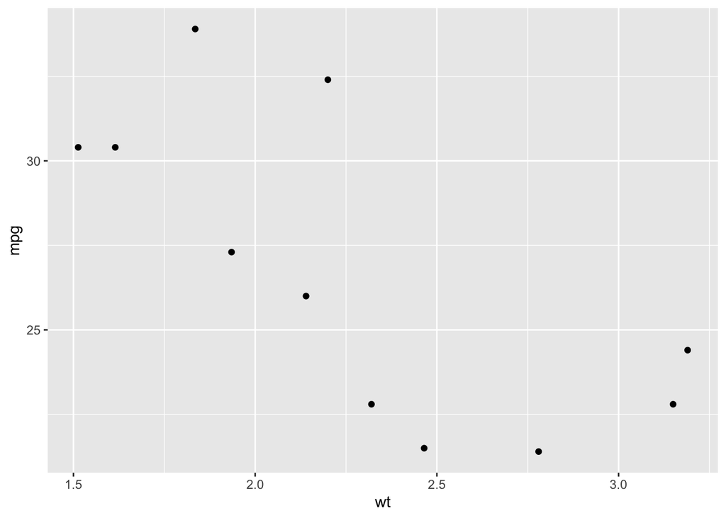

```
##
## $`6`
```

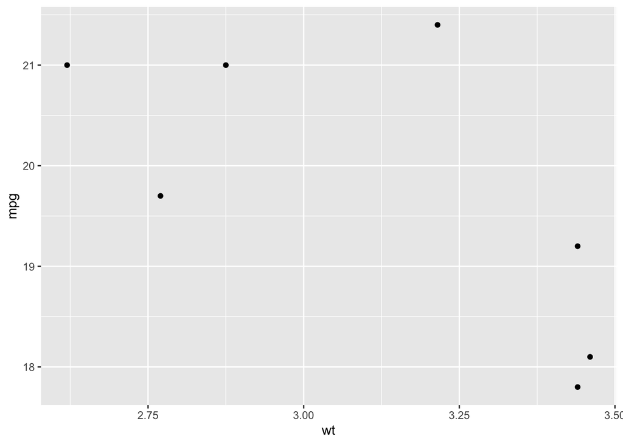

```
##
## $`8`
```

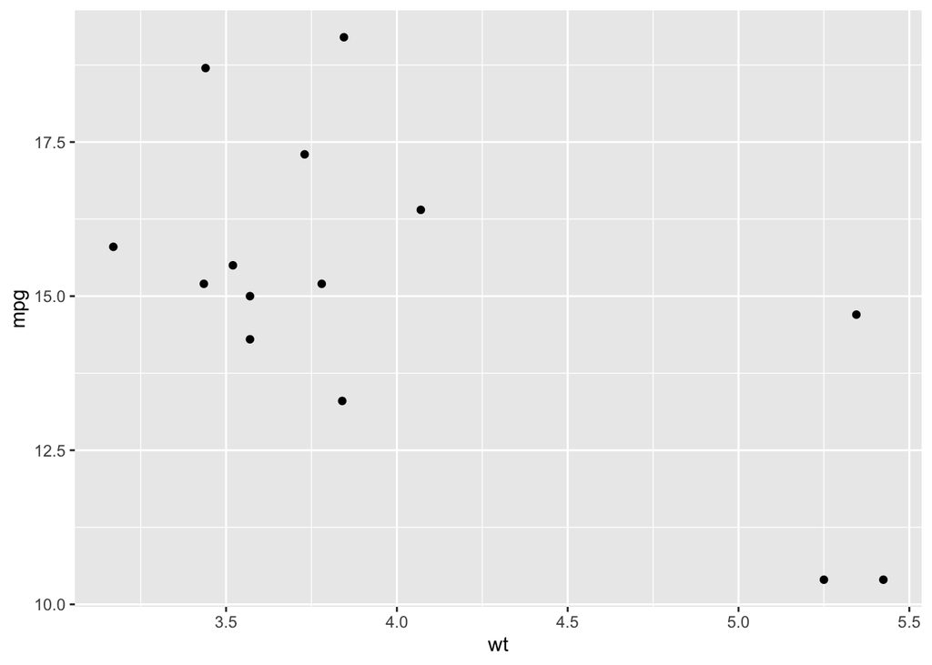

```r
mtcars %>%
  split(.$cyl) %>%
  map(~ggplot(., aes(wt, mpg))+geom_point())
```

*Example 4*: Compute the number of unique values in each column.

```r
.x<-iris[[1]]
length(unique(.x))
```

```
## [1] 35
```

```r
map(iris, ~ length(unique(.x)))
```

```
## $Sepal.Length
## [1] 35
##
## $Sepal.Width
## [1] 23
##
## $Petal.Length
## [1] 43
##
## $Petal.Width
## [1] 22
##
## $Species
## [1] 3
```

*Example 5*: Fix the missing values:

```r
df<- tibble(
  a= c(rnorm(9), -99),
  b<-c(-999, -99, rnorm(8))
)

df
```

```
## # A tibble: 10 × 2
##          a `b <- c(-999, -99, rnorm(8))`
##      <dbl>                         <dbl>
##  1   0.603                      -999
##  2  -1.78                        -99
##  3   0.335                        -1.77
##  4   0.561                         0.189
##  5   1.22                         -0.366
##  6  -0.211                         1.06
##  7   0.699                        -0.742
##  8  -0.706                        -1.35
##  9  -0.465                        -0.517
## 10 -99                             1.41
```

```r
fix_missing <- function(x) {
  x[x == -99] <- NA
  x
}
```

```r
map(df, fix_missing)
```

```
## $a
##  [1]  0.6031613 -1.7838441  0.3349422  0.5609757  1.2209357 -0.2114536
##  [7]  0.6994295 -0.7064367 -0.4651509         NA
##
## $`b <- c(-999, -99, rnorm(8))`
##  [1] -999.0000000           NA   -1.7661986    0.1892886   -0.3661807
##  [6]    1.0576012   -0.7416215   -1.3483591   -0.5173064    1.4117357
```